# My Stata usage isn’t what it used to be

Gabi Huiber

Thursday, September 11, 2014

## My programming life

I learned [Stata](http://www.stata.com/) in 2000 for a job as a teaching assistant for an econometrics class at Clemson. I used it on my first full-time job at UPS, for writing my dissertation, and even for [parenting my first-born](http://enoriver.net/index.php/2009/08/30/parenting-with-stata/). I liked Stata a lot.

In the winter of 2007 I dabbled briefly in [R](http://cran.r-project.org/) and abandoned it because I could see no advantage over Stata for anything that I was doing at the time. Then between 2008 and 2010 I took some [CS classes at NCSU](http://engineeringonline.ncsu.edu/PS/CPC.html). Those changed my thinking about how to organize computer programs. [Data structures](http://www2.acs.ncsu.edu/reg_records/crs_cat/CSC.html#CSC%20316) was particularly enlightening and gave me an appreciation for [Mata](http://www.stata.com/features/matrix-programming-mata/).

In the fall of 2011 I took [Andrew Ng’s machine learning class](https://www.coursera.org/course/ml) from Stanford Online that went on to be one of the first offerings on Coursera. This class used [Octave](http://www.gnu.org/software/octave/) for programming, which struck me as similar to Mata, but more expressive. I know that this is a matter of taste; I mean that I could do stuff in Octave more conveniently than I could in Mata. I liked Octave a lot.

In the spring of 2012 I took [Gov-2001](http://projects.iq.harvard.edu/gov2001/). It used R for applications and homework. It struck me that R was like Mata, but more expressive (see above). By summer of that year my programming was about evenly split between R and Stata.

Then in the fall of 2012 I took Computing for Data Analysis – now [R Programming](https://www.coursera.org/course/rprog) – on Coursera. That is when I started using R more, and Stata less, both at work and at home.

## The current state of my Stata use

My [`profile.do`](http://www.stata.com/support/faqs/programming/profile-do-file/) file starts a command log every time I fire up Stata. This command log has the date in its name, and it will record stuff I do at the Stata command line for days if I don’t shut down the computer or close Stata. These logs are saved in `data/cmdlogs` on the machines where I have Stata installed – my work PC and my own Mac.

So, a simple `dir` or `ls` on this directory will give me a pretty good idea of my Stata usage history over the years since 2011, when I started keeping tabs on my current computers. Unfortunately, this history doesn’t look too good for Stata.

My logs get shorter over time. Below is a tabulation of mean log sizes, by year:

```
##         where year  bytes
## 1: On work PC 2011 1702.3
## 2: On work PC 2012 1784.5
## 3: On work PC 2013 1362.7
## 4: On work PC 2014   40.0
## 5: On own Mac 2011 4073.3
## 6: On own Mac 2012 6012.4
## 7: On own Mac 2013 1790.3
## 8: On own Mac 2014  119.3
```

```
##
##        On own Mac On work PC
##   2011         73         35
##   2012         88         37
##   2013         38         30
##   2014          6          2
```

Below is a timeline. The very large spikes correspond to logs that stayed open for many days, whenever instead of shutting down the computer I just let it sleep, with Stata on. I used to tinker a lot with Stata on my own time, but in 2012 I also had a good stretch where I got to use my own Mac for work. This is not allowed as often as this plot might suggest; this was a job where I used a lot of simulated data, so the client had no information security concerns.

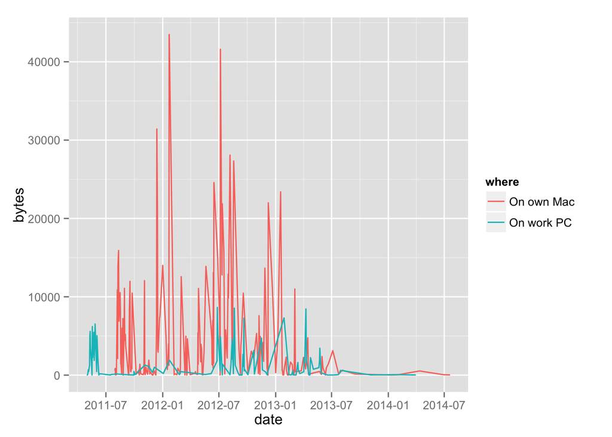

I don’t use Stata much anymore. I miss it a little and I still feel kinship with Stata users, but my customers want their work done in R. This is not what I expected when I started my current job four years ago. I thought I would have to switch to SAS.